# R Notebook

> Adapted from Federico Abascal’s practical

# Detection of drivers in bladder carcinoma

We will be working with a dataset of bladder cancer from the TCGA consortium.

## Generating the input ﬁle

dndscv works with an input ﬁle that consist of 5 columns. 1) Sample ID 2) Chromosome 3) Position 4) Reference 5) Mutation

We can extract this data from MAF ﬁles columns:

1. Tumor_Sample_Barcode
2. Chromosome
3. Start_Position
4. Reference_Allele
5. Tumor_Seq_Allele2

The input ﬁle can also be generated from vcf ﬁles using the following columns:

1. Tumor column (column number can diﬀer based on the tool used to generate the vcf ﬁle)
2. Chrom
3. POS
4. REF
5. ALT

For this practical we have already prepared an input ﬁle for you TCGA-BLCA.5col. However, in your own work, you will have to typically generate this input ﬁle on your own. The easiest way to structure this input is by converting your variant calling output (.vcf formatted ﬁle) to .maf format. (See earlier discussion on the topic)

## Data loading and exploration

Once we have an appropriately formatted 5 column input ﬁle with a suitable header we should load the data and explore it to ensure that the data are what we expect them to be and to check for any unexpected errors.

### Load the input ﬁle

```r
library(dndscv)
setwd("~/Downloads/Bioinformatica_Avanzada/mutational_signatures/BLCA-mutational-signatures-2")

muts = read.table("example_BLCA/TCGA-BLCA.5col", header = TRUE, sep = "\t", stringsAsFactors = FALSE)
head(muts)
```

|  | sampleID | chr | pos | ref | mut |
| --- | --- | --- | --- | --- | --- |
| 1 | TCGA-2F-A9KO | 10 | 101715548 | C | T |
| 2 | TCGA-2F-A9KO | 10 | 102822569 | G | A |
| 3 | TCGA-2F-A9KO | 10 | 103826020 | C | T |
| 4 | TCGA-2F-A9KO | 10 | 104160055 | G | C |
| 5 | TCGA-2F-A9KO | 10 | 118666167 | C | T |
| 6 | TCGA-2F-A9KO | 10 | 12043694 | C | G |

To count the number of samples we can run the next command

```r
length(unique(muts$sampleID))
```

```
## [1] 370
```

and to get the number of mutations:

```r
nrow(muts)
```

```
## [1] 53518
```

There are $370$ donors and $53518$ mutations. To see the mutational burden per sample we can run the following:

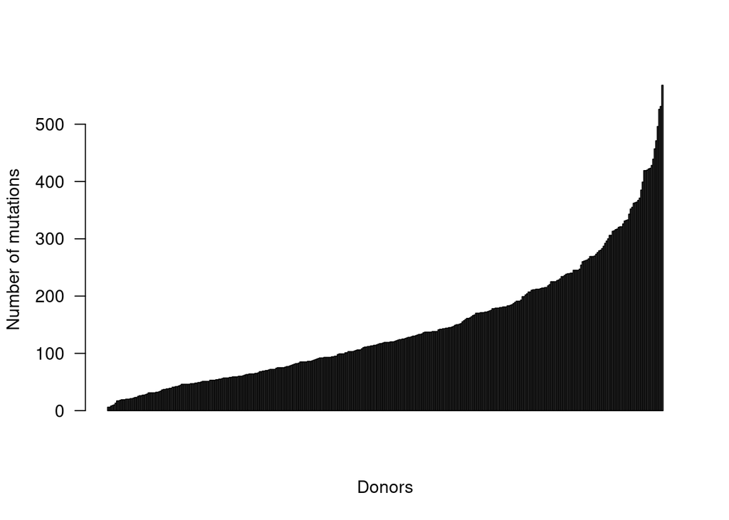

```r
barplot(sort(table(muts$sampleID)), ylab = "Number of mutations", xlab = "Donors",  las = 2, names.arg = "")
```

### Are there any hypermutators in the cohort?

> *It is relevant to explore our data in this way because hypermutators can have a negative impact on the statistical power to detect drivers and because some hypermutators (e.g. POLE mutant tumors) are under mutational processes not properly modeled by a trinucleotide-substitution model. Although there is no exact deﬁnition of a hypermutator, usually having more than 500 mutations in the exome (approximately 5.6810^{4} mutations in the whole genome) can be considered a hypermutator. In general, it is good to exclude these samples from this analysis.*